# 2-1-jupyter-ecosystem slides

(Presentation; 30 min)

R. Burke Squires

https://github.com/burkesquires

## Jupyter? What Is In A Name?

The name has its origins in a few different places.

- **First**, the names comes from the planet Jupiter. We wanted to pick a name that evoked the **traditions and ideas of science**.
- **Second**, the core programming languages supported by Jupyter are **Ju**lia, **Py**thon and **R**. While the name Jupyter is not a direct acronym for these languages, it nods its head in those directions. In particular, the "y" in the middle of Jupyter was chosen to honor our Python heritage. See the logos of these languages in the languages folder of this repo.
- **Third**, **Galileo** was the first person to discover the moons of Jupiter. His **publication on the moons of Jupiter** is an early example of research that includes the underlying data in the publication. This is one of the core ideas and requirements for scientific reproducibility. Reproducibility is one of the main focuses of our project.

## Philosophy

Project Jupyter's operating philosophy is to **support interactive data science and scientific computing across all programming languages via the development of open-source software**. According to the Project Jupyter website, "Jupyter will always be 100% open-source software, free for all to use and released under the liberal terms of the modified BSD license."

## A Short History

### November 2001

#### IPython

- "Just an afternoon hack"
- 259 Line Python script.
- Plotting, Numerics, interactive workflow.

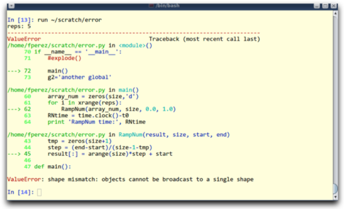

### 2011

#### iPython Notebook

- Rich web client
- Text & math
- Code
- Results
- Share, reproduce

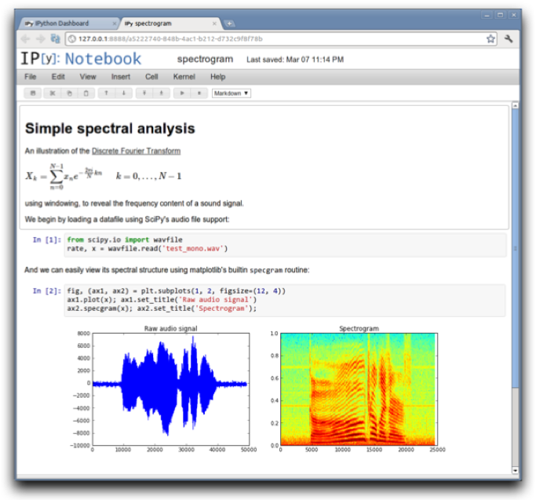

### 2013

- Alfred P. Sloan Foundation announced that it would support IPython development for two years.
- Fernando Perez was awarded the Free Software Foundation Advancement of Free Software award for IPython.
- Microsoft made a donation of $100,000 to sponsor IPython’s continued development.

### 2014

- Project Jupyter spuns off
  - IPython continues to exist as a Python shell and kernel for Jupyter,
  - Notebook interface and other language-agnostic parts of IPython were moved under the Jupyter name.
  - Jupyter is language agnostic
- Won the Jolt Productivity Award from Dr. Dobb's in the category of coding tools.

### 2015

- Won $6 million from Gordon and Betty Moore Foundation, Alfred P. Sloan Foundation and Leona M. and Harry B. Helmsley Charitable Trust.

### 2018

- Awarded the 2017 ACM Software System Award. It is the largest team to have won the award.
- Initial official JupyterLab release

### Today

- 500+ contributors
- Multiple GitHub orgs, >120 repos
- Hundreds of thousands of lines of code, multiple languages
- At least 4 million users ~ $8M in direct funding ~ 25 full-time developers (academia, industry, non-profits)

## Jupyter Ecosystem

[figure not shown]

See also: https://jupyter.readthedocs.io/en/latest/architecture/how_jupyter_ipython_work.html

### Jupyter Notebook

Jupyter Notebook (Formerly IPython Notebooks) is a web-based interactive computational environment for creating Jupyter notebooks documents.

- The "notebook" term can colloquially make reference to many different entities, mainly the Jupyter web application, Jupyter python web server, or Jupyter document format depending on context.
- A JSON document, following a versioned schema, and containing an ordered list of input/output cells
- Can contain code, text (using Markdown), mathematics, plots and rich media, usually ending with the ".ipynb" extension.

### Jupyter kernels

- Program responsible for **handling various types of request** (code execution, code completions, inspection), and providing a reply.
- Kernels **talks to the other components** of Jupyter using ZeroMQ over the network, and thus **can be on the same or remote machines**.
- Unlike many other Notebook-like interface, in Jupyter, **kernels are not aware they are attached to a specific document**, and can be **connected to from many client at once**. Usually Kernels are implemented and allow execution of a single language with a couple of exceptions.
- **By default Jupyter ships with IPython** as a default kernel and reference implementation via the ipykernel wrapper. Kernels of various quality and features for many languages are available.
- NOTE: **SoS - multi-language kernel** (https://github.com/vatlab/SoS)

### Kernels

https://github.com/jupyter/jupyter/wiki/Jupyter-kernels

### Jupyter Lab

- Next-generation user interface for Project Jupyter.
- It offers all the familiar building blocks of the classic Jupyter Notebook (notebook, terminal, text editor, file browser, rich outputs, etc.) in a flexible and powerful user interface. - First stable release was announced on February 20, 2018.

### JupyterHub

- JupyterHub is a multi-user server for Jupyter Notebooks.
- It is designed to support many users by spawning, managing, and proxying many singular Jupyter Notebook servers.

### Adoption

- GitHub displays a static form of Jupyter notebooks

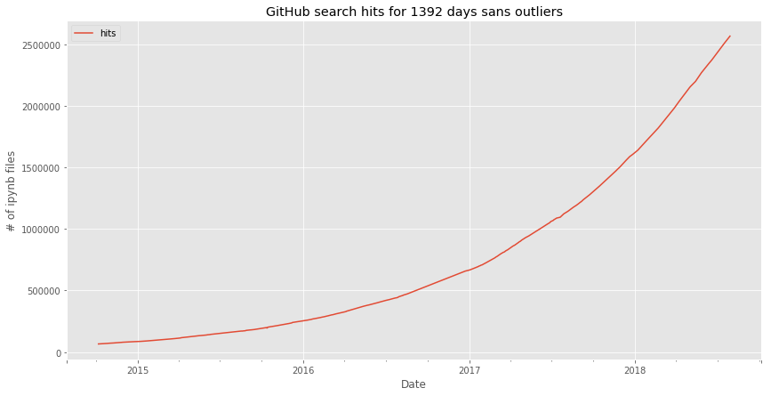

GitHub project to estimate the number of jupyter notebooks: https://github.com/parente/nbestimate

### Projects Incorporating Jupyter Notebooks

- Kbase
- Galaxy
- GenePattern
- PyCharm Python IDE

### Industry Adoption

- Google's Colaboratory
- Amazon's SageMaker Notebooks
- Microsoft's Azure Notebook

### Notebook Gallery

- https://github.com/jupyter/jupyter/wiki/A-gallery-of-interesting-Jupyter-Notebooks
- http://nbviewer.jupyter.org